# Most Fatal and Most Costly Weather Phenomena in the US from 1950-2008

Charin Polpanumas

February 3, 2559 BE

### Synopsis

This report answers the questions of which types of weather phenomena are most harmful to population health and which have the largest economic impact. It utilizes the [NOAA Storm Database](https://www.ncdc.noaa.gov/stormevents/) to visualize such events. During the period from January 1950 to November 2008, tornadoes by far have caused the most injuries and deaths; flood has caused the highest amount of property damages and economic consequences overall while drought has caused the higest amount of crop damages.

### Data Processing

#### Preprocessing

Download [Storm Data](https://d396qusza40orc.cloudfront.net/repdata%2Fdata%2FStormData.csv.bz2) from the [NOAA Storm Database](https://www.ncdc.noaa.gov/stormevents/) and read it into *storm* data.frame

```r
download.file(url='https://d396qusza40orc.cloudfront.net/repdata%2Fdata%2FStormData.csv.bz2',
              destfile = 'StormData.csv.bz2')
storm<-read.csv(bzfile("StormData.csv.bz2"))
```

Examine data summary and parts of the data set.

```r
str(storm)
```

```
## 'data.frame':    902297 obs. of  37 variables:
##  $ STATE__   : num  1 1 1 1 1 1 1 1 1 1 ...
##  $ BGN_DATE  : Factor w/ 16335 levels "1/1/1966 0:00:00",..: 6523 6523 4242 11116 2224 2224 2260 383 3980 3980 ...
##  $ BGN_TIME  : Factor w/ 3608 levels "00:00:00 AM",..: 272 287 2705 1683 2584 3186 242 1683 3186 3186 ...
##  $ TIME_ZONE : Factor w/ 22 levels "ADT","AKS","AST",..: 7 7 7 7 7 7 7 7 7 7 ...
##  $ COUNTY    : num  97 3 57 89 43 77 9 123 125 57 ...
##  $ COUNTYNAME: Factor w/ 29601 levels "","5NM E OF MACKINAC BRIDGE TO PRESQUE ISLE LT MI",..: 13513 1873 4598 10592 4372 10094 1973 23873 24418 4598 ...
##  $ STATE     : Factor w/ 72 levels "AK","AL","AM",..: 2 2 2 2 2 2 2 2 2 2 ...
##  $ EVTYPE    : Factor w/ 985 levels "   HIGH SURF ADVISORY",..: 834 834 834 834 834 834 834 834 834 834 ...
##  $ BGN_RANGE : num  0 0 0 0 0 0 0 0 0 0 ...
##  $ BGN_AZI   : Factor w/ 35 levels "","  N"," NW",..: 1 1 1 1 1 1 1 1 1 1 ...
##  $ BGN_LOCATI: Factor w/ 54429 levels ""," Christiansburg",..: 1 1 1 1 1 1 1 1 1 1 ...
##  $ END_DATE  : Factor w/ 6663 levels "","1/1/1993 0:00:00",..: 1 1 1 1 1 1 1 1 1 1 ...
##  $ END_TIME  : Factor w/ 3647 levels ""," 0900CST",..: 1 1 1 1 1 1 1 1 1 1 ...
##  $ COUNTY_END: num  0 0 0 0 0 0 0 0 0 0 ...
```

[output cut: 23 more lines]

Subset the data for only what we need: types of events, fatalities, injuires, property damages and their magnitudes, and crop damages and their magnitudes.

```r
storm<- subset(storm, select=c('EVTYPE','FATALITIES','INJURIES','PROPDMG','PROPDMGEXP','CROPDMG','CROPDMGEXP'))
```

#### Data Transformation

Notice that PROPDMGEXP and CROPDMGEXP serve as magnitude variables. Therefore, we must transform these variables to get the proper property and crop damages in USD.

##### Transform PROPDMG and PROPDMGEXP to PROP

Examine the unique levels of magnitudes.

```r
unique(storm$PROPDMGEXP)
```

```
##  [1] K M   B m + 0 5 6 ? 4 2 3 h 7 H - 1 8
## Levels:  - ? + 0 1 2 3 4 5 6 7 8 B h H K m M
```

Create PROPEXP for numerical representation of PROPDMGEXP

```r
storm$PROPEXP[storm$PROPDMGEXP == "K"] <- 1000
storm$PROPEXP[storm$PROPDMGEXP == "M"] <- 1e+06
storm$PROPEXP[storm$PROPDMGEXP == ""] <- 1
storm$PROPEXP[storm$PROPDMGEXP == "B"] <- 1e+09
storm$PROPEXP[storm$PROPDMGEXP == "m"] <- 1e+06
storm$PROPEXP[storm$PROPDMGEXP == "0"] <- 1
storm$PROPEXP[storm$PROPDMGEXP == "5"] <- 1e+05
storm$PROPEXP[storm$PROPDMGEXP == "6"] <- 1e+06
storm$PROPEXP[storm$PROPDMGEXP == "4"] <- 10000
storm$PROPEXP[storm$PROPDMGEXP == "2"] <- 100
storm$PROPEXP[storm$PROPDMGEXP == "3"] <- 1000
storm$PROPEXP[storm$PROPDMGEXP == "h"] <- 100
storm$PROPEXP[storm$PROPDMGEXP == "7"] <- 1e+07
storm$PROPEXP[storm$PROPDMGEXP == "H"] <- 100
storm$PROPEXP[storm$PROPDMGEXP == "1"] <- 10
storm$PROPEXP[storm$PROPDMGEXP == "8"] <- 1e+08
# Invalid entries
storm$PROPEXP[storm$PROPDMGEXP == "+"] <- 0
storm$PROPEXP[storm$PROPDMGEXP == "-"] <- 0
storm$PROPEXP[storm$PROPDMGEXP == "?"] <- 0
```

Create PROP variable by multiplying property damages with their magnitudes

```r
storm$PROP<- storm$PROPDMG*storm$PROPEXP
```

##### Transform CROPDMG and CROPDMGEXP to CROP

Examine the unique levels of magnitudes.

```r
unique(storm$CROPDMGEXP)
```

```
## [1]   M K m B ? 0 k 2
## Levels:  ? 0 2 B k K m M
```

Create CROPEXP for numerical representation of CROPDMGEXP

```r
storm$CROPEXP[storm$CROPDMGEXP == "M"] <- 1e+06
storm$CROPEXP[storm$CROPDMGEXP == "K"] <- 1000
storm$CROPEXP[storm$CROPDMGEXP == "m"] <- 1e+06
storm$CROPEXP[storm$CROPDMGEXP == "B"] <- 1e+09
storm$CROPEXP[storm$CROPDMGEXP == "0"] <- 1
storm$CROPEXP[storm$CROPDMGEXP == "k"] <- 1000
storm$CROPEXP[storm$CROPDMGEXP == "2"] <- 100
storm$CROPEXP[storm$CROPDMGEXP == ""] <- 1
# Invalid Entries
storm$CROPEXP[storm$CROPDMGEXP == "?"] <- 0
```

Create CROP variable by multiplying crop damages with their magnitudes

```r
storm$CROP<- storm$CROPDMG*storm$CROPEXP
```

#### Aggregate Data by Event Types

```r
fatalities<-aggregate(FATALITIES~EVTYPE,data=storm,FUN=sum)
injuries<-aggregate(INJURIES~EVTYPE,data=storm,FUN=sum)
prop<-aggregate(PROP~EVTYPE,data=storm,FUN=sum)
crop<-aggregate(CROP~EVTYPE,data=storm,FUN=sum)

#Change unit to billion USD
prop$PROP<-prop$PROP/1e+09
crop$CROP<-crop$CROP/1e+09
#overall economic damages
overall<-merge(prop,crop,by.x='EVTYPE',by.y='EVTYPE')
overall$OVERALL <- overall$PROP+overall$CROP
```

### Results

#### Events with Most Fatalities and Injuries

Get top 10 events with fatalities and injuries

```r
fa10<-fatalities[order(-fatalities$FATALITIES), ][1:10, ]
in10<-injuries[order(-injuries$INJURIES), ][1:10, ]
```

Plot fatalities and injuries according to event types. Tornadoes top both categories.

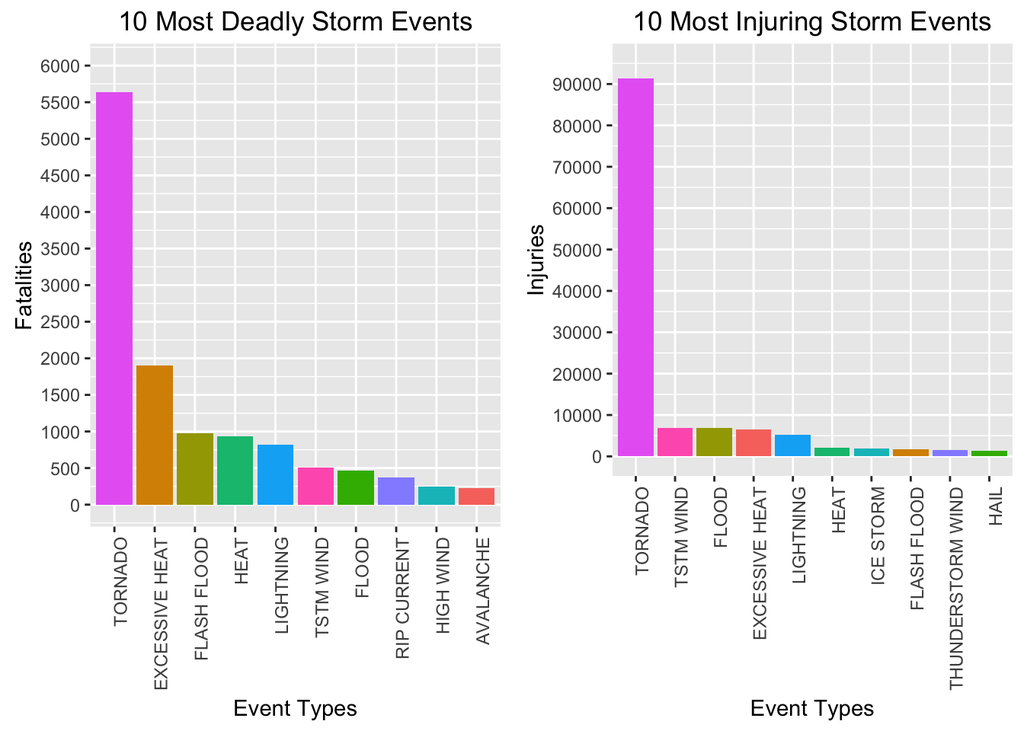

```r
require(ggplot2)
require(gridExtra)
#For fatalities
g1<-ggplot(fa10, aes(x=reorder(EVTYPE,-FATALITIES),y=FATALITIES,fill=EVTYPE))
g1<-g1+geom_bar(stat='identity')
g1<-g1+scale_y_continuous(limits=c(0,6000),breaks=seq(0, 6000, 500))
g1<-g1+labs(x='Event Types',y='Fatalities',title='10 Most Deadly Storm Events')
g1<-g1+theme(axis.text.x = element_text(angle = 90, hjust = 1), legend.position='none')

#For injuries
g2<-ggplot(in10, aes(x=reorder(EVTYPE,-INJURIES),y=INJURIES,fill=EVTYPE))
g2<-g2+geom_bar(stat='identity')
g2<-g2+scale_y_continuous(limits=c(0,95000),breaks=seq(0, 95000, 10000))
g2<-g2+labs(x='Event Types',y='Injuries',title='10 Most Injuring Storm Events')
g2<-g2+theme(axis.text.x = element_text(angle = 90, hjust = 1), legend.position='none')

#Plot fatalities and injuries
grid.arrange(g1,g2,ncol=2)
```

#### Events with Most Property and Crop Damages

Get top 10 events with property,crop and overall damages.

```r
pr10<-prop[order(-prop$PROP), ][1:10, ]
cr10<-crop[order(-crop$CROP), ][1:10, ]
ov10<-overall[order(-overall$OVERALL), ][1:10, ]
```

Plot property, crop, and overall damages according to event types. Flood tops property and overall damages whereas drought tops crop damages.

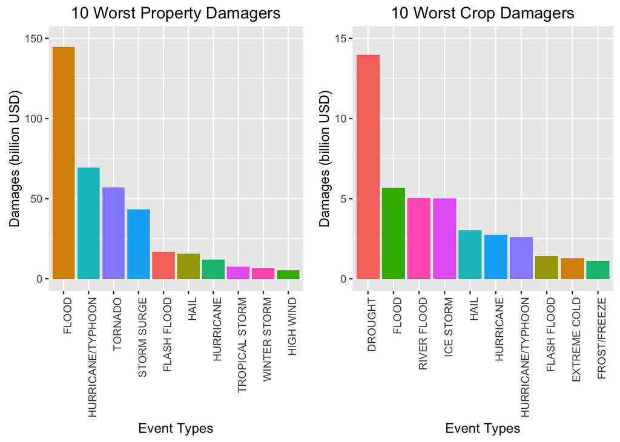

```r
require(ggplot2)
require(gridExtra)

#For property damages
g3<-ggplot(pr10, aes(x=reorder(EVTYPE,-PROP),y=PROP,fill=EVTYPE))
g3<-g3+geom_bar(stat='identity')
g3<-g3+scale_y_continuous(limits=c(0,150),breaks=seq(0, 150, 50))
g3<-g3+labs(x='Event Types',y='Damages (billion USD)',title='10 Worst Property Damagers')
g3<-g3+theme(axis.text.x = element_text(angle = 90, hjust = 1), legend.position='none')

#For crop damages
g4<-ggplot(cr10, aes(x=reorder(EVTYPE,-CROP),y=CROP,fill=EVTYPE))
g4<-g4+geom_bar(stat='identity')
g4<-g4+scale_y_continuous(limits=c(0,15),breaks=seq(0, 15, 5))
g4<-g4+labs(x='Event Types',y='Damages (billion USD)',title='10 Worst Crop Damagers')
g4<-g4+theme(axis.text.x = element_text(angle = 90, hjust = 1), legend.position='none')

#For overall damages in stacked barplot
require(reshape2)
#Reshape ov10
mov10<-melt(ov10)
mov10<-mov10[mov10$variable!='OVERALL',]
#Sort EVTYPE according to overall damage
l <-ov10$EVTYPE
mov10$EVTYPE<-factor(mov10$EVTYPE,levels=l)

g5<-ggplot(mov10, aes(x=EVTYPE,y=value,fill=variable))
g5<-g5+geom_bar(stat='identity')
g5<-g5+scale_y_continuous(limits=c(0,160),breaks=seq(0, 160, 50))
g5<-g5+labs(x='Event Types',y='Damages (billion USD)',title='10 Most Costly Storm Events')
g5<-g5+theme(axis.text.x = element_text(angle = 90, hjust = 1),legend.title=element_blank())

#Plot prop vs crop and overall
grid.arrange(g3,g4,ncol=2)
```

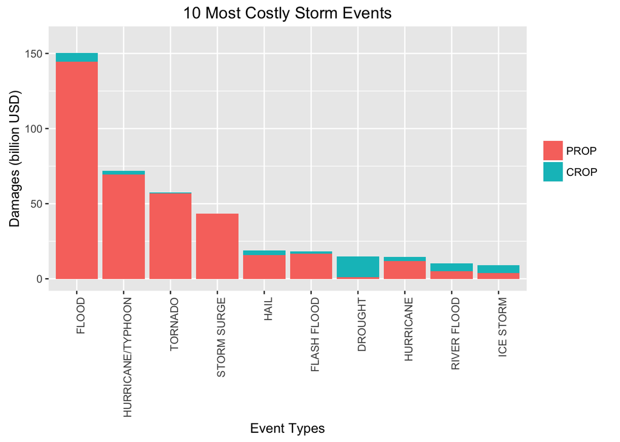

```r
g5
```

### Conclusion

- Tornadoes are most deadly.
- Flood is real estate’s and the economy’s worst enemy.
- Drought is the worst crop killer.